# practice_set

This notebook contains solutions to all the problems in the given problem set. Each question is presented with:

1. Description of question in markdown cell.
2. The Python solution in a code cell.
3. Output in a markdown cell.

# Q1.

1. generate natural list.
2. now loop it and apply operations.
3. Then we can find mean median and standard deviation.

```python
import numpy as np
l = []
sum = 0
product = 1
# This is used to create a list of natural numbers.
for i in range(1, 21):
    l.append(i)

for i in l:
    if i%2==0:
        sum+=i
    else:
        product*=i
print(f'sum: {sum} Product: {product}')
mean = np.mean(l)
median = np.median(l)
std = np.std(l)
print(mean, median, std)
```

# Q2. Explain mutable and immutable data types.

Immutable data types -> The data types which, once defined, have items in them can not be changed further. for eg, String, tuples, integers, floats mutable data types -> The data types that, once defined, we can change the items in themselves. fo eg: lists, Dictionaries, set, bytearray

# Q3. Fibbonaci series

```python
import matplotlib.pyplot as plt
n = int(input("Enter the number of terms: "))
l = [0, 1]
if n == 0:
    l = []
elif n == 1:
    l = [0]
else:
    a = l[0]
    b = l[1]
    for i in range(2, n):
        a, b = b, a + b
        l.append(b)

x = [i for i in range(n)]

plt.plot(x, l)

plt.xlabel("Number of terms")
plt.ylabel("Fibonacci series")
plt.title("Fibonacci series")

plt.show()
```

[output not shown]

# Q4. List Manipulation

```python
import numpy as np
l = [3, 5, 7, 9, 11, 13]
l.insert(3, 6) # Add 6 at the index 3 of the list.
l.remove(7) # remove 7 from the list.
l.reverse() # Reverse the list.
mean = np.mean(l)
median = np.median(l)
print(l)
print(f'mean : {mean}')
print(f'median : {median}')
```

Output: [13, 11, 9, 6, 5, 3] mean : 7.833333333333333 median : 7.5

# Q5.

```python
import matplotlib.pyplot as plt
import numpy as np

# Example data (an iterable such as a list or tuple)
data = list(map(int, input().split(", ")))
mean = np.mean(data)
print(min(data), max(data))

# Plot the histogram
plt.hist(data, bins=9, edgecolor='black')

# Adding labels and title
plt.xlabel('Values')
plt.ylabel('Frequency')
plt.title('Histogram of Data')

# Show the plot
plt.show()
```

[output not shown]

# Q6.

```python
from functools import reduce
inp = input().lower()
n = inp.split(" ")
n1 = inp[::-1].split(" ")

def s(x, y):
    return x + y

string = reduce(s, n)
string_reverse = reduce(s ,n1)

if string == string_reverse:
    print(True)
else:
    print(False)
```

```
True
```

# Q7.

```
Average marks:  6.0
Arpan
Ayush
```

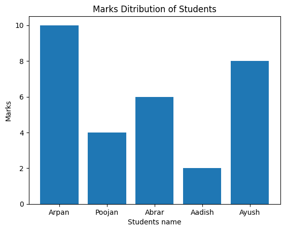

```python
import matplotlib.pyplot as plt
import numpy as np

student = {}

for _ in range(int(input("Enter number of Students: "))):
    name = input("Enter name: ").strip()
    marks = int(input("Enter marks: ").strip())
    student[name] = marks

student_name = list(student.keys())
marks = list(student.values())

avg_marks = np.mean(marks)

print("Average marks: ", avg_marks)
for key, value in student.items():
    if value > avg_marks:
        print(key)

plt.bar(student_name, marks)

# Adding labels and title
plt.xlabel('Students name')
plt.ylabel('Marks')

plt.title('Marks Ditribution of Students')

# Display the chart
plt.show()
```

# Q8.

```
[(0, 0), (1, 1), (2, 4), (3, 9), (4, 16), (5, 25), (6, 36), (7, 49), (8, 64), (9, 81), (10, 100), (11, 121), (12, 144), (13, 169), (14, 196), (15, 225), (16, 256), (17, 289), (18, 324), (19, 361)]
```

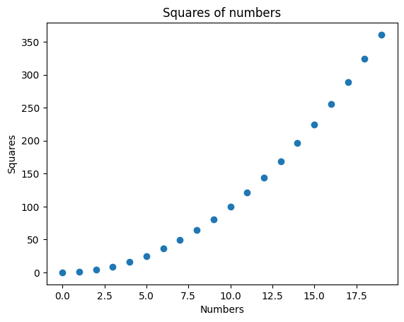

```python
import matplotlib.pyplot as plt
l = []
x = []
y = []
for i in range(int(input("Enter the number till you want squares: "))):
    l.append((i, i**2))
    x.append(i)
    y.append(i**2)
print(l)

plt.scatter(x, y)
plt.xlabel('Numbers')
plt.ylabel('Squares')
plt.title('Squares of numbers')
plt.show()
```

# Q9.

We can do this by using dict comphrension

```python
dict1 = {'a': 10, 'b': 20}
dict2 = {'b': 5, 'c': 15}
output = {key: dict1.get(key, 0) + dict2.get(key, 0) for key in dict1 | dict2} # | is union operator.
print(output)
```

```
{'a': 10, 'b': 25, 'c': 15}
```

# Q10.

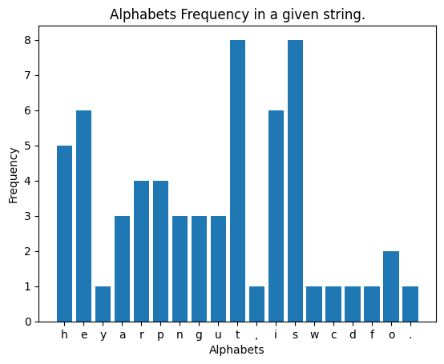

```python
from collections import defaultdict
from matplotlib import pyplot as plt
my_dict = defaultdict(int)
n = input("Enter a string: ")
n = n.lower().split()
n = "".join(n)
for i in n:
    my_dict[i] += 1

key = list(my_dict.keys())
value = list(my_dict.values())

plt.bar(key, value)

plt.xlabel('Alphabets')
plt.ylabel('Frequency')
plt.title(f'Alphabets Frequency in a given string.')

plt.show()
```

# Q11.

```python
import numpy as np
l = [1, 2, 4, 1, 5, 2 , 4, 5, 8, 9]

unique_list = list(dict.fromkeys(l))
mean = np.mean(unique_list)
median = np.median(unique_list)

print(f'''unique list: {unique_list}
Mean: {mean}
Median: {median}''')
```

```
unique list: [1, 2, 4, 5, 8, 9]
Mean: 4.833333333333333
Median: 4.5
```

# Q12.

```
Longest string is:  Bharti
[5, 5, 6, 6]
```

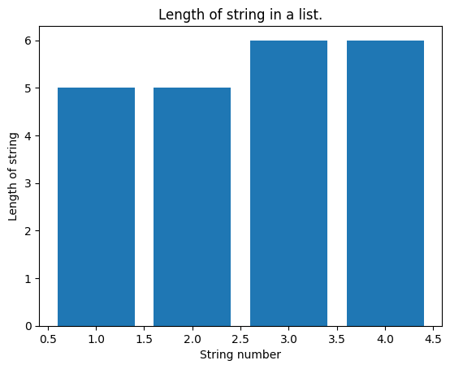

```python
import matplotlib.pyplot as plt
l=[]
for _ in range(int(input("Enter number of string you want to add: "))):
    s = input("Enter string: ").strip()
    l.append(s)
l_len = [len(i) for i in l]
long_s = l[l_len.index(max(l_len))]

print("Longest string is: ",long_s)
print(l_len)

plt.bar([i for i in range(1, len(l)+1)], l_len)
plt.xlabel("String number")
plt.ylabel("Length of string")
plt.title("Length of string in a list.")
plt.show()
```

# Q13.

```python
data = [{'name': 'Alice', 'age': 25}, {'name': 'Bob', 'age': 22}]

sorted_data = sorted(data, key=lambda x: x['age'])

# How The above code of line will work as.
#     1. The sorted(iterable, key=none, value=none) function returns a new sorted list from the elements of any iterable.
#          The key takes a function which is applies to every iterable and the value returned by that function sorting will be done on the basis of that data.
#     2. The lambda function is a small anonymous function. which take x as an argument and return x['age'] as a value.
#          Here, x will be the dict of the data, and x['age'] will return the age of the person.
#     3. So the sorting will be done on the basis of the age of the person.

print(sorted_data)
```

```
[{'name': 'Bob', 'age': 22}, {'name': 'Alice', 'age': 25}]
```

# Q14.

```
['Hello', 'buddy', 'friend', 'loving', 'your']
```

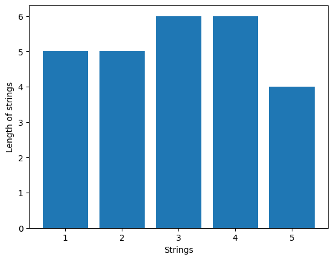

```python
import matplotlib.pyplot as plt
n = input().split()
def stringlen_more4(n):
    if len(n) >= 4:
        return True
    return False
result = list(filter(stringlen_more4, n))
result.sort()
length = [len(i) for i in result]
print(result)
plt.bar([i for i in range(1, len(result) + 1)], length)
plt.xlabel('Strings')
plt.ylabel('Length of strings')
plt.show()
```

# Q15.

Anagrams are those in which both words has same character with identical frequency and case-insestive.

```python
import json
words = json.loads(input("Enter the list of words: "))
word= input("Enter the word of which you want to find anagram: ")
def anagram(word, words):
    return [w for w in words if sorted(w.lower()) == sorted(word.lower())]
# Here it checks foreach word in words now check that sorted of that word and given word is same if same then it is angram
print(anagram(word, words))
```

```
['Arpan', 'napra', 'apran']
```

# Q.16

symmetric difference -> (A∪B)−(A∩B) => i.e the list of elements In python we can do it by ^ or A.symmetric_difference(B)

```
Union:  25
Intersection:  10
Symmetric Difference:  15
```

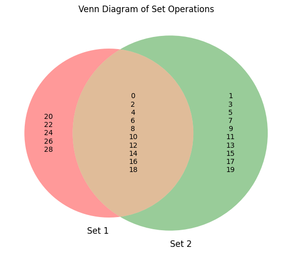

```python
from matplotlib_venn import venn2, venn3
import matplotlib.pyplot as plt

l = set([i for i in range(30) if i % 2 == 0])
l1 = set([i for i in range(20)])
# I want to find union of l and l1
union = l |  l1 # | -> this is used for union
intersection = l & l1 # & -> this is used for intersection
sym_difference = l ^ l1 # - -> this is used for symmetric difference.

print("Union: ", len(union))
print("Intersection: ", len(intersection))
print("Symmetric Difference: ", len(sym_difference))

plt.figure(figsize=(8, 6)) # This is used to determine the sixe of the figure.
venn = venn2([set(l), set(l1)], ('Set 1', 'Set 2'))  # Labels for sets
plt.title("Venn Diagram for 2 Sets")

# Annotate the results in the diagram
venn.get_label_by_id('10').set_text('\n'.join(map(str, l - l1)))  # Elements in section 1
# Here 10 refers to the elements which are only in Set 1 (set ma ha or set 2 ma nhi)
venn.get_label_by_id('01').set_text('\n'.join(map(str, l1 - l)))  # Elements only in Set 2
# Here 01 refers to the elements which are only in Set 2 (set2 ma ha or set1 ma nhi)
venn.get_label_by_id('11').set_text('\n'.join(map(str, intersection)))  # Intersection
# Here 11 refers to the elements which are in both the sets (set1 ma ha or set2 ma ha)

# Add title
plt.title("Venn Diagram of Set Operations")

plt.show()
```

# Q.17

```python
l = [12, 13, 24, 10, 90, 98, 69, 48]
sum_n = 0
print(sum(l))
# this is for writing in a file.
with open('n.txt', 'w') as f:  # Here e are opening it in writing mode not in appending
    for i in l:
        f.write(str(i) + '\n')
# This is for reading data from the file.
with open('n.txt', 'r') as f:
    num = f.readlines()
    for i in num:
        sum_n += int(i)
print(sum_n)
```

[output not shown]

# Q.18

```python
This is our n.txt file content.

In Python, sets are unordered collections of unique elements, meaning they don't maintain the order of insertion. However, if you want to preserve the order while extracting unique elements from a list, you can use a combination of a set to filter out duplicates and a list to maintain order.
You can do this by iterating through the list while checking if the element is already in the set. Here's how you can achieve this.
With Transcrypt, you can handle events in Python in a similar way to JavaScript by binding events to elements. Transcrypt allows you to write event-driven web applications using Python, making it a bridge between Python and JavaScript for web development.

If you are using other Python-to-JavaScript tools like Brython, the syntax is slightly different but the concept remains the same: you interact with the DOM and add event listeners just as you would in JavaScript, but using Pythonic syntax.
```

```python
# # Q18
import matplotlib.pyplot as plt
from collections import defaultdict
l = defaultdict(int)
with open('n.txt', 'r') as f:
    data = f.read().split()
    for i in data:
        l[i] += 1
word, freq = zip(*l.items())  # This will separate the keys and values of the dictionary into two separate lists by unpacking the dictionary using zip
max_freq = max(freq)
max_freq_words = [key for key, value in l.items() if value == max_freq]
print(f'The most frequent word is "{', '.join(max_freq_words)}" and it occurs {max_freq} times.')
plt.bar(word, freq)
plt.xticks(word, rotation=90) # This will rotate the x-axis labels by 90 degrees
plt.yticks(freq, rotation='horizontal')
plt.title(f'Frequency of words.')
plt.show()
```

[output not shown]

# Q.19

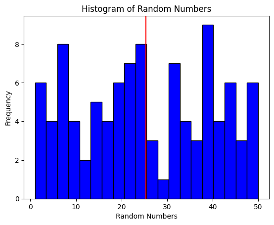

```python
import random
import numpy as np
import matplotlib.pyplot as plt
# Here we have generated a file which has 100 random number between 1 and 50 inclusuvely.
with open('random.txt', 'w') as f:
    for i in range(100):
        f.write(str(random.randint(1, 50)) + '\n')

with open('random.txt', 'r') as f:
    data = f.readlines()
    data = list(map(int, data))
    mean = np.mean(data)

plt.hist(data, bins=20, color='blue', edgecolor='black')
plt.xlabel('Random Numbers')
plt.ylabel('Frequency')
plt.title('Histogram of Random Numbers')
plt.axvline(mean, color='red', label='Mean') # Mean line of red color.
plt.show()
```

# Q.20

To read a csv file using python Let our value is present in 3colums in file i.e. [Name, class, marks] then first we get list of all lines then apply for loop and iterate a line then split the line with ',' and take the value at 2nd index i.e. 3rd column and start storing in a list to use that for visualization.

This is my rough1.csv file Arpan, 1, 80 Arpan, 2, 70 Arpan, 3, 50 Arpan, 4, 60 Arpan, 5, 80 Arpan, 6, 70 Arpan, 7, 90 Arpan, 8, 80 Arpan, 9, 97 Arpan, 10, 94 Arpan, 11, 90 Arpan, 12, 92

```python
import matplotlib.pyplot as plt
marks = []
clas = []
with open('rough1.csv', 'r') as f:
    data = f.readlines()
    for i in data:
        marks.append(int(i.split(',')[2].strip()))
        clas.append(int(i.split(',')[1].strip()))
sum_marks = sum(marks)
plt.plot(clas, marks)
plt.xlabel('Class')
plt.ylabel('Marks')
plt.title('Marks vs Class of Arpan')
plt.show()
```

[output not shown]

```
Mean: 34.833333333333336, Median: 33.0, Mode: 14, Standard Deviation: 19.227439882741656
```

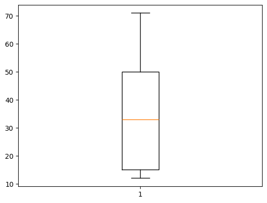

```python
# Q.21
import numpy as np
import statistics
import matplotlib.pyplot as plt

lst = [14, 21, 33, 44, 52, 61, 71, 18, 59, 60, 14, 21, 14, 33, 42, 44, 12, 14]
mean = np.mean(lst)
std = np.std(lst)
median = np.median(lst)
mode = statistics.mode(lst)
print(f'Mean: {mean}, Median: {median}, Mode: {mode}, Standard Deviation: {std}')
# The key takes a function and return the key by passing each iterable element to the function and according that it max is calculated

plt.boxplot(lst)

plt.show()
```

```python
# Q.22
l = [45, 64, 23, 80, 86,  4, 99,  9, 84]
normalized_l = [(i-min(l))/(max(l)-min(l)) for i in l] # It is normalises to 0-1.
print(normalized_l)
```

```
[0.43157894736842106, 0.631578947368421, 0.2, 0.8, 0.8631578947368421, 0.0, 1.0, 0.05263157894736842, 0.8421052631578947]
```

```python
# Q.23
n = int(input("Enter the number: "))
if n>=0:
    if n%2 ==0 :
        print("Even")
    else:
        print("Odd")
else:
    print("Even or odd is not defined for -ve numbers.")
```

```
Even
```

```python
# Q.24
n = int(input("Enter your score: "))
if n>90:
    print("A")
elif n>80:
    print("B")
elif n>70:
    print("C")
elif n>60:
    print("D")
else:
    print("F")
```

```python
Q.25
For the leap the year should be divisible by 4 and by 100 only if it is divisible by 400.
i.e. the year which is divisible by 4 and not 100 or divided by 400 are leap year.
```

```python
n = int(input("Enter year: "))
if (n % 400 == 0) or (n % 4 == 0 and n % 100 != 0):
    print("Leap year")
else:
    print("Not a leap year")
```

```
Leap year
```